# Homework Assignment 2

DA 4 - CEU 2018

Kristof Menyhert

2018-02-17

#### Description:

In this exercise I predicted the bankrupcy of firms in a given dataset.

First I created 3 models:

- Logit model with GLMnet
- Decision tree model
- Random Forest model

Then Evaluated them and picked a model wiht the best prediction power.

#### Load packages and the data:

Load libraries and set the theme:

```r
library(data.table)
library(caret)
library(knitr)
library(ggplot2)
library(tidyr)
library(rpart)
library(rattle)
library(h2o)
library(ROCR)

theme_set(theme_bw()) #globally set ggplot theme to black & white
options(scipen=999) #disable scientific notation
```

Load the data:

```r
data <- fread("C:/Users/menyh/OneDrive - Central European University/R/da4_hw2/bisnode_all.csv")
```

#### In the following lines I transform my data in order to be easily analizable. I create the sales of previous years and profit_loss of previous years for further use:

I would like to use the previous years of sales, sales change in percent and the same for profit_loss:

```r
#######
### Create previouse sales varibles:
#######


data_for_wide <- data[, c("comp_id", "sales", "year")] #which columns I would like to keep for the wide transformation

data_wide <- spread(data_for_wide, key = year, value = sales)
#rename columns:
colnames(data_wide)[2] <- "sales_2011"
colnames(data_wide)[3] <- "sales_2012"
colnames(data_wide)[4] <- "sales_2013"
colnames(data_wide)[5] <- "sales_2014"
colnames(data_wide)[6] <- "sales_2015"
colnames(data_wide)[7] <- "sales_2016"

data_wide <- data_wide[, sales_difference_2016_2015 := sales_2016 - sales_2015]
data_wide <- data_wide[, sales_difference_percent_2016_2015 := sales_2016/sales_2015]

data_wide <- data_wide[, sales_difference_2015_2014 := sales_2015 - sales_2014]
data_wide <- data_wide[, sales_difference_percent_2015_2014 := sales_2015/sales_2014]

data_wide <- data_wide[, sales_difference_2014_2013 := sales_2014 - sales_2013]
data_wide <- data_wide[, sales_difference_percent_2014_2013 := sales_2014/sales_2013]

data_wide <- data_wide[, sales_difference_2013_2012 := sales_2013 - sales_2012]
data_wide <- data_wide[, sales_difference_percent_2013_2012 := sales_2013/sales_2012]

data_wide <- data_wide[, sales_difference_2012_2011 := sales_2012 - sales_2011]
data_wide <- data_wide[, sales_difference_percent_2012_2011 := sales_2012/sales_2011]


#######
### Create previouse profit and loss varibles:
#######

data_for_wide2 <- data[, c("comp_id", "profit_loss_year", "year")] #which columns I would like to keep

data_wide2 <- spread(data_for_wide2, key = year, value = profit_loss_year)
#rename columns:
colnames(data_wide2)[2] <- "profit_loss_year_2011"
colnames(data_wide2)[3] <- "profit_loss_year_2012"
colnames(data_wide2)[4] <- "profit_loss_year_2013"
colnames(data_wide2)[5] <- "profit_loss_year_2014"
colnames(data_wide2)[6] <- "profit_loss_year_2015"
colnames(data_wide2)[7] <- "profit_loss_year_2016"

data_wide2 <- data_wide2[, profit_loss_difference_2016_2015 := profit_loss_year_2016 - profit_loss_year_2015]
data_wide2 <- data_wide2[, profit_loss_difference_percent_2016_2015 := profit_loss_year_2016/profit_loss_year_2015]

data_wide2 <- data_wide2[, profit_loss_difference_2015_2014 := profit_loss_year_2015 - profit_loss_year_2014]
data_wide2 <- data_wide2[, profit_loss_difference_percent_2015_2014 := profit_loss_year_2015/profit_loss_year_2014]

data_wide2 <- data_wide2[, profit_loss_difference_2014_2013 := profit_loss_year_2014 - profit_loss_year_2013]
data_wide2 <- data_wide2[, profit_loss_difference_percent_2014_2013 := profit_loss_year_2014/profit_loss_year_2013]

data_wide2 <- data_wide2[, profit_loss_difference_2013_2012 := profit_loss_year_2013 - profit_loss_year_2012]
data_wide2 <- data_wide2[, profit_loss_difference_percent_2013_2012 := profit_loss_year_2013/profit_loss_year_2012]

data_wide2 <- data_wide2[, profit_loss_difference_2012_2011 := profit_loss_year_2012 - profit_loss_year_2011]
data_wide2 <- data_wide2[, profit_loss_difference_percent_2012_2011 := profit_loss_year_2012/profit_loss_year_2011]
```

#### Coose a year which I would like to exlore:

I choose the the year 2014 therefore, I am going to inspect those firms which went bankrupt from 2014 to 2015.

```r
data <- data[year %in% c(2014)] #keep only year 2014 obserrvaions
```

Merge back the previously created variables: * Previous sales * Previous profit and loss

```r
data <- merge(x = data, y = data_wide, by = "comp_id", all.x = TRUE)
data <- merge(x = data, y = data_wide2, by = "comp_id", all.x = TRUE)
```

(obs number: 28151)

Filter those firms which have NA or 0 or very low sales in 2014

```r
data <- data[!is.na(sales_2014)]
data <- data[sales_2014 > 150]
```

(obs number: 22190)

#### In the next part I am crating the “deafult”" variable:

As per the tasks requirements I need to create a default variable which is a dummy variable indicating whether a given firm is defaulted or not in the next year (1 = defaulted/ 0 = not defaulted).

I am doing this in a separated table, then I merge my indicator back to the full dataset.

```r
### Do some filtering:
data_for_flag <- data[, .(comp_id, sales_2014, sales_2015, sales_2016, sales_difference_percent_2015_2014, sales_difference_percent_2016_2015)]

data_for_flag <- data_for_flag[is.na(sales_2015), sales_2015 := 0]
data_for_flag <- data_for_flag[is.na(sales_2016), sales_2016 := 0]

data_for_flag <- data_for_flag[,sales_difference_percent_2015_2014:= sales_2015/sales_2014]
data_for_flag <- data_for_flag[,sales_difference_percent_2016_2015 := sales_2016/sales_2015]
data_for_flag <- data_for_flag[,sales_difference_percent_2016_2014 := sales_2016/sales_2014]

data_for_flag <- data_for_flag[is.nan(sales_difference_percent_2015_2014), sales_difference_percent_2015_2014 := 0]
data_for_flag <- data_for_flag[is.nan(sales_difference_percent_2016_2015), sales_difference_percent_2016_2015 := 0]
data_for_flag <- data_for_flag[is.nan(sales_difference_percent_2016_2014), sales_difference_percent_2016_2014 := 0]
```

My definition for bankruptcy is that if a given firm sales disappear from the database or drops 90% or more in the next year (for 2015) + sales are not given or not rise back to the same level as it is in 2014 the next year (for 2016) I indicate my firm as bankrupt.

See this condition below:

```r
#Conditon for bankruptcy:
data_for_flag <- data_for_flag[, bankrupt := ifelse(sales_difference_percent_2015_2014 <= 0.1 & sales_difference_percent_2016_2014 <= 0.1, 1, 0)]
```

Merging back to the full data:

```r
data_for_flag <- data_for_flag[, .(comp_id, bankrupt)] #drop those columns which I do not need, keep only comp_id and the indicator

#actuall merging:
data <- merge(data, data_for_flag, by = "comp_id", all.x = TRUE)
```

Now in my dataset I have columns/variables which are related to the future. Am getting rid of them, as our preposition is that we do not know nothing about our firms in 2014 for the year 2015 and year 2016 only whether that they go bankrupt or not in 2015 base on our definition.

Drop columns which are related to the future. We do not know nothing about them in 2014:

```r
data[, c("sales_2015",
         "sales_2016",
         "sales_difference_2016_2015",
         "sales_difference_2015_2014",
         "sales_difference_percent_2016_2015",
         "sales_difference_percent_2015_2014",
         "profit_loss_year_2015",
         "profit_loss_year_2016",
         "profit_loss_difference_2016_2015",
         "profit_loss_difference_2015_2014",
         "profit_loss_difference_percent_2016_2015",
         "profit_loss_difference_percent_2015_2014"):=NULL]
```

For simplicity reasons I decided to use only those firms which have not zero sales for all the years before (from 2011 to 2014) from 2011 to 2014. And reported not zero profit loss.

**So our model will only be able to predict bankruptcy for those firms which are at least 4 years old and have not 0 sales in all the years.**

I am doing this because otherwise the percentage change for these variables are not giving reasonable values. (Na, NaN or Inf values will be created.)

```r
data <- data[!is.na(sales_2011) & !is.na(sales_2012) & !is.na(sales_2013) & !is.na(sales_2014)] #Drop NA sales --> obs number: 16984

data <- data[sales_2011 != 0 & sales_2012 != 0 & sales_2013 != 0 & sales_2014 !=0] # Drop 0 sales --> obs number: 15631

data <- data[!is.na(profit_loss_year_2011) & !is.na(profit_loss_year_2012) & !is.na(profit_loss_year_2013) & !is.na(profit_loss_year_2014)] # Drop NA profit and loss --> obs number: 15631

data <- data[profit_loss_year_2011 != 0 & profit_loss_year_2012 != 0 & profit_loss_year_2013 != 0 & profit_loss_year_2014 !=0] # Drop 0 profit and loss --> obs number: 14164
```

Now I have a Dataset which I am able to analyze

## EDA:

#### Inspect our target variable:

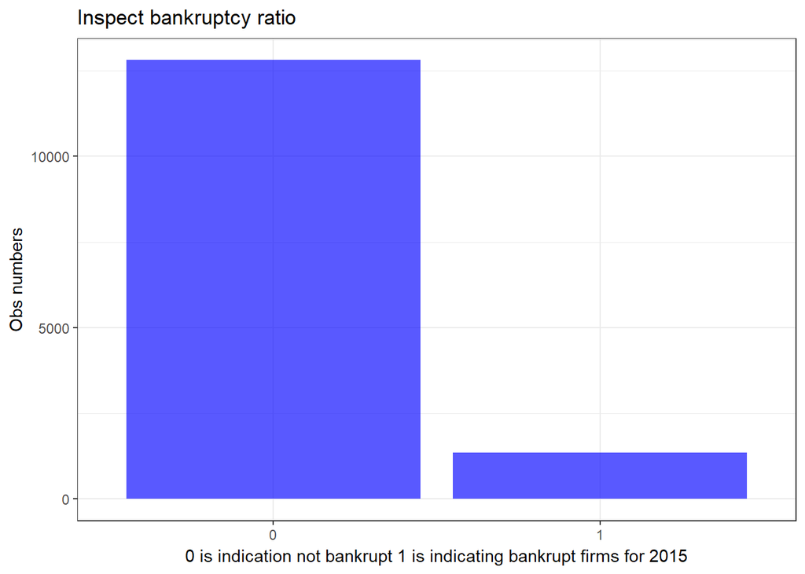

```r
ggplot(data, aes(as.factor(bankrupt))) + geom_bar(fill = "blue", alpha = 0.65) + labs(title ="Inspect bankruptcy ratio", y = "Obs numbers", x = "0 is indication not bankrupt 1 is indicating bankrupt firms for 2015")
```

Exact number:

```r
summary(as.factor(data$bankrupt))
```

```
##     0     1
## 12811  1353
```

#### Inspect some variables which might cotribute to bankrupcy:

**Founded year variable:**

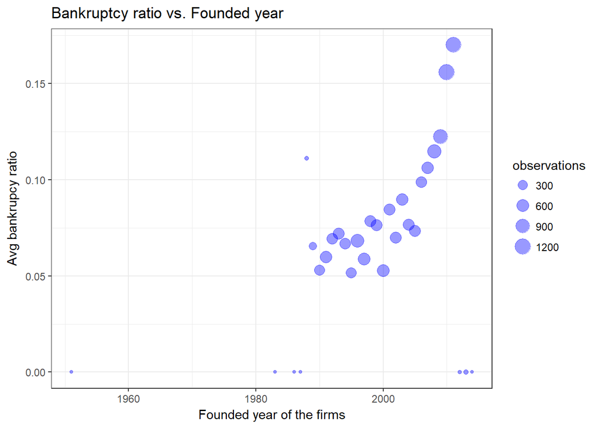

```r
data <- data[!is.na(founded_year)] #drop where there is NA --> obs number: 13785

toplot <- data[, .(mean = mean(bankrupt), observations = .N), by = founded_year]
ggplot(toplot, aes(x = founded_year, y = mean, size = observations)) + geom_point(alpha = 0.4, color = "blue") + labs(title ="Bankruptcy ratio vs. Founded year", y = "Avg bankrupcy ratio", x = "Founded year of the firms")
```

We can see some relationship, which is not linear, so I will use the poly() function later on.

**Curr_asset variable:**

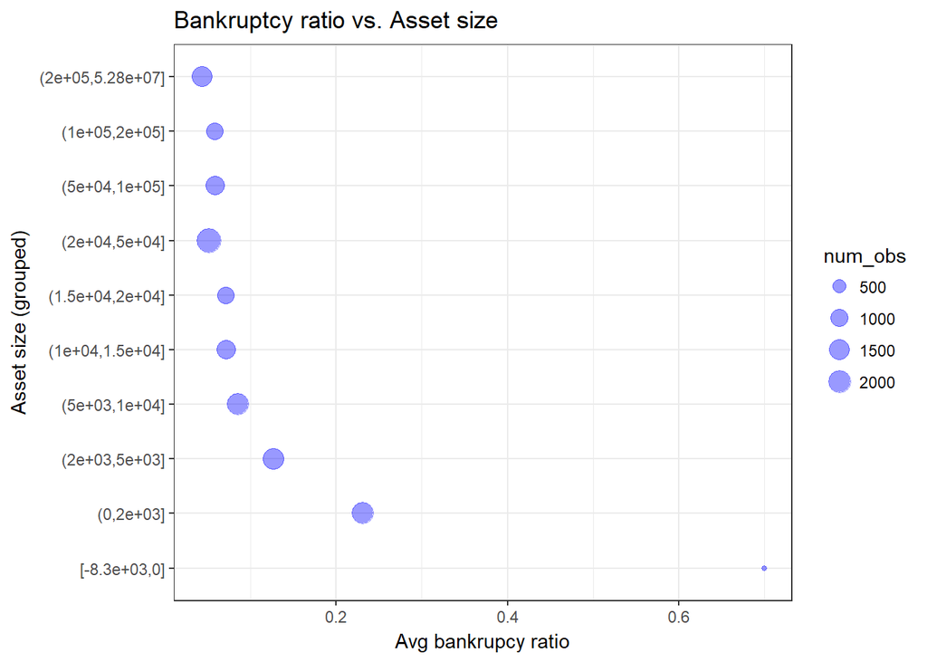

```r
data <- data[!is.na(curr_assets)] #drop NAs --> obs number: 13785 --> no drop

data_by_curr_asset <- data[,
  .(bank_rate = mean(bankrupt), num_obs = .N),
  keyby = .(curr_asset_cat = cut(curr_assets, breaks = c(min(data$curr_assets), 0, 2000, 5000, 10000, 15000, 20000, 50000, 100000, 200000, max(data$curr_assets)),
  include.lowest = TRUE))]

ggplot(data_by_curr_asset, aes(x = curr_asset_cat, y = bank_rate, size = num_obs)) + geom_point(alpha = 0.4, color = "blue") +  labs(title ="Bankruptcy ratio vs. Asset size", y = "Avg bankrupcy ratio", x = "Asset size (grouped)") + coord_flip()
```

As the asset size decreasing the bankruptcy ratio is increasing, especially for firms with small asset size.

**curr_liab variable:**

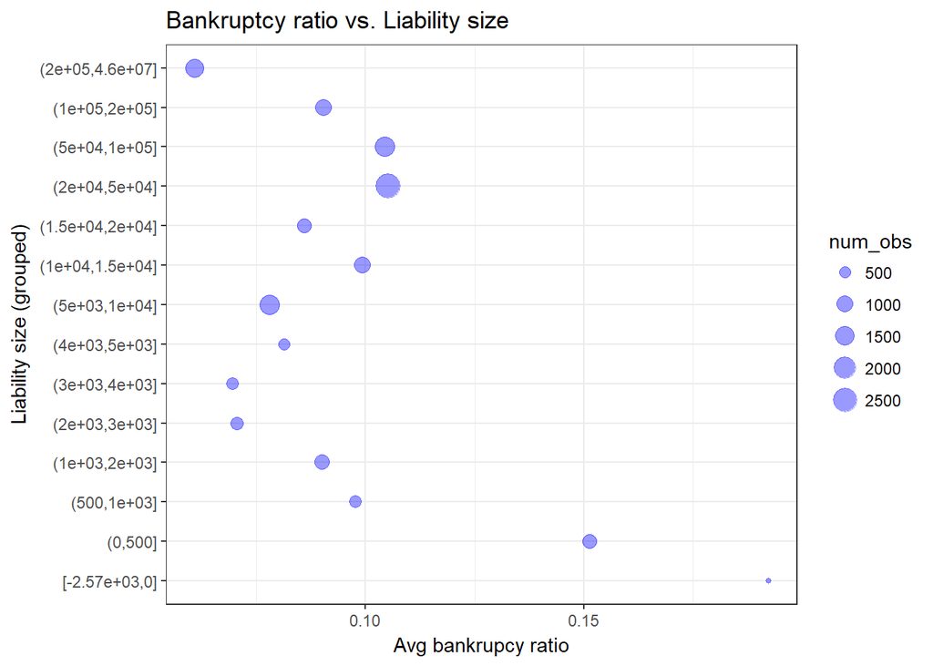

```r
data <- data[!is.na(curr_liab)] #drop NAs --> obs number: 13785 --> no drop

data_by_curr_liab <- data[,
  .(bank_rate = mean(bankrupt), num_obs = .N),
  keyby = .(curr_liab_cat = cut(curr_liab, breaks = c(min(data$curr_liab), 0, 500, 1000, 2000, 3000, 4000, 5000, 10000, 15000, 20000, 50000, 100000, 200000, max(data$curr_liab)),
  include.lowest = TRUE))]

ggplot(data_by_curr_liab, aes(x = curr_liab_cat, y = bank_rate, size = num_obs)) + geom_point(alpha = 0.4, color = "blue") + labs(title ="Bankruptcy ratio vs. Liability size", y = "Avg bankrupcy ratio", x = "Liability size (grouped)") + coord_flip()
```

Liability size pattern is not clear.

**curr_liab-curr_asset variable:**

I created a new variable which is the difference of curr_liab and curr_asset variables.

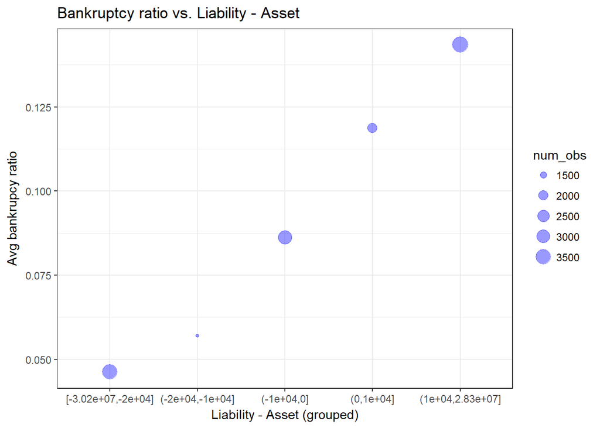

```r
data[, curr_liab_minus_asset := curr_liab - curr_assets]

data <- data[!is.na(curr_liab_minus_asset)] #drop NAs --> obs number: 13785 --> no drop

data_by_curr_liab_minus_asset <- data[,
  .(bank_rate = mean(bankrupt), num_obs = .N),
  keyby = .(curr_liab_minus_asset_cat = cut(curr_liab_minus_asset, breaks = c(min(data$curr_liab_minus_asset), -20000, -10000, 0, 10000, max(data$curr_liab_minus_asset)),
  include.lowest = TRUE))]

ggplot(data_by_curr_liab_minus_asset, aes(x = curr_liab_minus_asset_cat, y = bank_rate, size = num_obs)) + geom_point(alpha = 0.4, color = "blue") + labs(title ="Bankruptcy ratio vs. Liability - Asset", y = "Avg bankrupcy ratio", x = "Liability - Asset (grouped)")
```

**Ceo_count variable:**

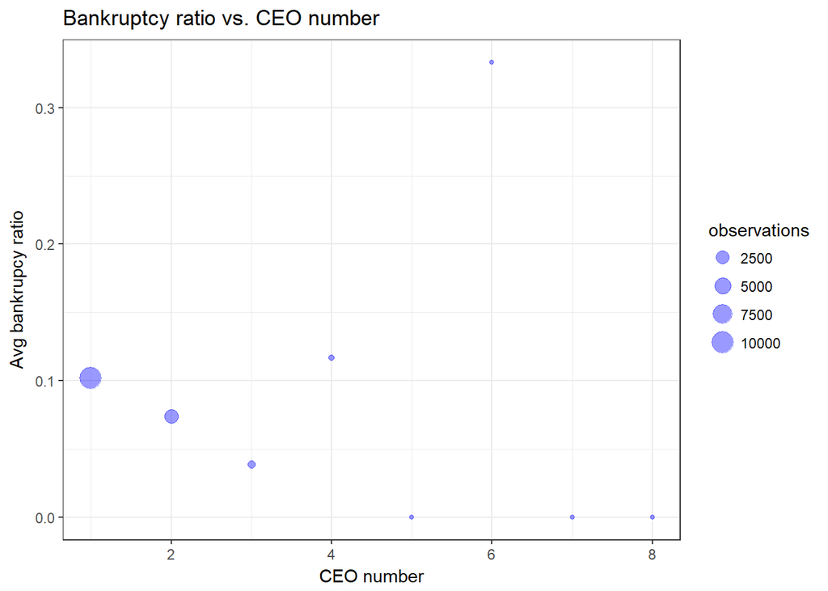

```r
data <- data[!is.na(ceo_count)] #drop NAs --> obs number: 13785 --> no drop
toplot <- data[, .(mean = mean(bankrupt), observations = .N), by = ceo_count]
ggplot(toplot, aes(x = ceo_count, y = mean, size = observations)) + geom_point(alpha = 0.4, color = "blue") + labs(title ="Bankruptcy ratio vs. CEO number", y = "Avg bankrupcy ratio", x = "CEO number")
```

**Origin:**

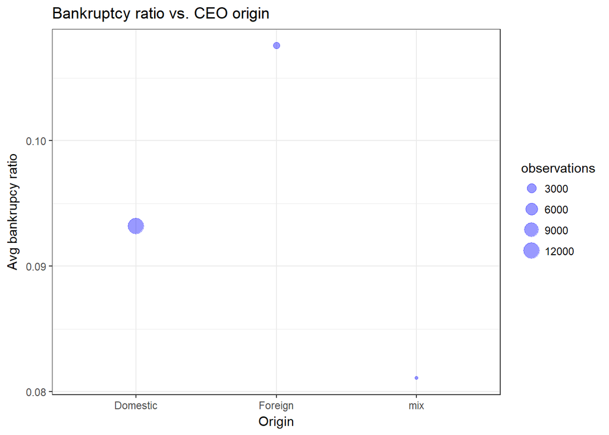

```r
data$origin <- as.factor(data$origin)

data <- data[!is.na(origin)] #drop NAs --> obs number: 13785 --> no drop

toplot <- data[, .(mean = mean(bankrupt), observations = .N), by = origin]

ggplot(toplot, aes(x = origin, y = mean, size = observations)) + geom_point(alpha = 0.4, color = "blue") + labs(title ="Bankruptcy ratio vs. CEO origin", y = "Avg bankrupcy ratio", x = "Origin")
```

## Do some other stuff before spliting our data to train and test data:

#### Create a Yes/No variable based on the bankrupcy variable for the models. This is going to be useful later on:

```r
data[, bankrupt_yes_no := ifelse(bankrupt == 1, "Yes", "No")]
data[, bankrupt_yes_no := factor(bankrupt_yes_no, levels = c("Yes", "No"))]
```

#### Fix NAs and creating factors of some other columns

```r
#gender:
data <- data[!is.na(gender)] #no drop
data$gender <- as.factor(data$gender)
#industry:
data <- data[!is.na(ind)] #no drop
data$ind <- as.factor(data$ind)
#region:
data <- data[!is.na(region_m)] #no drop
data$region_m <- as.factor(data$region_m)
```

#### Create Test and Train data:

```r
set.seed(1234)
cut <- createDataPartition(y = data$bankrupt, times = 1, p = 0.7, list = FALSE)
data_train <- data[cut, ]
data_test <- data[-cut, ]
```

## CREATING MODELS:

#### Logit with GLMnet model:

1st I create a logit model, with lots of variables. I use poly functions for the continuous variables as I do not know their exact functional forms I decided to use poly-3 for the modeling.

```r
glmnet_model <- train(bankrupt_yes_no ~ poly(curr_assets, 3) +
                        poly(curr_liab, 3) +
                        poly(curr_liab_minus_asset, 3) +
                        poly(founded_year, 3) +
                        poly(ceo_count, 3) +
                        origin +
                        gender +
                        ind +
                        region_m +
                        poly(sales_2014, 3) +
                        poly(sales_2013, 3) +
                        poly(sales_2012, 3)+
                        poly(sales_2011, 3) +
                        poly(sales_2014, 3) +
                        poly(sales_difference_percent_2014_2013, 3) +
                        poly(sales_difference_percent_2013_2012, 3) +
                        poly(sales_difference_percent_2012_2011, 3) +
                        poly(profit_loss_year_2014, 3) +
                        poly(profit_loss_year_2013, 3) +
                        poly(profit_loss_year_2012, 3) +
                        poly(profit_loss_year_2011, 3) +
                        poly(profit_loss_difference_percent_2014_2013, 3) +
                        poly(profit_loss_difference_percent_2013_2012, 3) +
                        poly(profit_loss_difference_percent_2012_2011, 3),
                   method = "glmnet",
                   metric = "ROC",
                   data = data_train,
                   trControl = trainControl(method = "cv",
                                            number = 5,
                                            classProbs = TRUE,
                                            summaryFunction=twoClassSummary),
                   tuneLength=5)

glmnet_model
```

```
## glmnet
##
## 9650 samples
##   23 predictor
##    2 classes: 'Yes', 'No'
##
## No pre-processing
## Resampling: Cross-Validated (5 fold)
## Summary of sample sizes: 7720, 7721, 7719, 7720, 7720
## Resampling results across tuning parameters:
##
##   alpha  lambda       ROC        Sens         Spec
##   0.100  0.002821814  0.6694401  0.007650273  0.9987411
##   0.100  0.013097701  0.6543930  0.003278689  0.9987411
##   0.325  0.002821814  0.6646529  0.005464481  0.9985122
##   0.325  0.013097701  0.6448191  0.001092896  0.9997710
##   0.550  0.002821814  0.6609310  0.005464481  0.9987411
##   0.550  0.013097701  0.6369007  0.001092896  0.9997710
##   0.775  0.002821814  0.6565044  0.004371585  0.9989701
##   0.775  0.013097701  0.6283563  0.000000000  0.9998855
##   1.000  0.002821814  0.6531803  0.003278689  0.9991988
##   1.000  0.013097701  0.6209387  0.000000000  1.0000000
##
## ROC was used to select the optimal model using the largest value.
## The final values used for the model were alpha = 0.1 and lambda
##  = 0.002821814.
```

#### Simple decision Tree model:

```r
tune_grid <- data.frame("cp" = c(0.0001, 0.0005, 0.001, 0.002, 0.005, 0.01, 0.1))

rpart_model <- train(bankrupt_yes_no ~ curr_assets +
                        curr_liab +
                        curr_liab_minus_asset +
                        founded_year +
                        ceo_count +
                        origin +
                        gender +
                        ind +
                        region_m +
                        sales_2014 +
                        sales_2013 +
                        sales_2012 +
                        sales_2011 +
                        sales_2014 +
                        sales_difference_percent_2014_2013 +
                        sales_difference_percent_2013_2012 +
                        sales_difference_percent_2012_2011 +
                        profit_loss_year_2014 +
                        profit_loss_year_2013 +
                        profit_loss_year_2012 +
                        profit_loss_year_2011 +
                        profit_loss_difference_percent_2014_2013 +
                        profit_loss_difference_percent_2013_2012 +
                        profit_loss_difference_percent_2012_2011,
                   data = data_train,
                   method = "rpart",
                   trControl = trainControl(method = "cv",
                              number = 10,
                              classProbs = TRUE,
                              summaryFunction=twoClassSummary),
                   tuneGrid = tune_grid,
                   metric = "ROC")

rpart_model
```

```
## CART
##
## 9650 samples
##   23 predictor
##    2 classes: 'Yes', 'No'
##
## No pre-processing
## Resampling: Cross-Validated (10 fold)
## Summary of sample sizes: 8686, 8686, 8686, 8685, 8685, 8685, ...
## Resampling results across tuning parameters:
##
##   cp      ROC        Sens       Spec
##   0.0001  0.7573321  0.2539178  0.9601654
##   0.0005  0.7566542  0.2462613  0.9630267
##   0.0010  0.7600273  0.2374821  0.9697807
##   0.0020  0.7128166  0.2101529  0.9781374
##   0.0050  0.6877700  0.1981844  0.9845474
##   0.0100  0.6705433  0.1380076  0.9884386
##   0.1000  0.5000000  0.0000000  1.0000000
##
## ROC was used to select the optimal model using the largest value.
## The final value used for the model was cp = 0.001.
```

#### Random forrest model:

In this part I am using the H2O library:

Start h2o:

```r
h2o.init(nthreads= -1, max_mem_size='6G')
```

Create the train data:

```r
trainHex <- as.h2o(data_train)
```

```r
features <- colnames(data_train)[(colnames(data_train) %in% c("curr_assets",
                                                            "curr_liab",
                                                            "curr_liab_minus_assets",
                                                            "founded_year",
                                                            "ceo_count",
                                                            "origin",
                                                            "gender",
                                                            "ind",
                                                            "region_m",
                                                            "sales_2014",
                                                            "sales_2013",
                                                            "sales_2012",
                                                            "sales_2011",             "sales_difference_percent_2014_2013",
                                                            "sales_difference_percent_2013_2012",
                                                            "sales_difference_percent_2012_2011",                               "profit_loss_year_2014",                                                            "profit_loss_year_2013",                                                            "profit_loss_year_2012",
                                                            "profit_loss_year_2011",
                                                            "profit_loss_difference_percent_2014_2013",
                                                            "profit_loss_difference_percent_2013_2012",
                                                            "profit_loss_difference_percent_2012_2011"
))]
```

```r
rfHex <- h2o.randomForest(x=features,
                          y="bankrupt_yes_no",
                          nfolds = 5,
                          ntrees = 100,
                          max_depth = 50,
                          nbins = 10,
                          stopping_metric = c("AUC"),
                          training_frame=trainHex)
```

```r
summary(rfHex)
```

```
## Model Details:
## ==============
##
## H2OBinomialModel: drf
## Model Key:  DRF_model_R_1518971741190_1520
## Model Summary:
##   number_of_trees number_of_internal_trees model_size_in_bytes min_depth
## 1             100                      100             1287138        26
##   max_depth mean_depth min_leaves max_leaves mean_leaves
## 1        41   32.54000        841       1128  1012.61000
##
## H2OBinomialMetrics: drf
## ** Reported on training data. **
## ** Metrics reported on Out-Of-Bag training samples **
##
## MSE:  0.07493947
## RMSE:  0.2737507
## LogLoss:  0.3145895
## Mean Per-Class Error:  0.3210263
## AUC:  0.7795382
## Gini:  0.5590763
##
## Confusion Matrix (vertical: actual; across: predicted) for F1-optimal threshold:
##          No  Yes    Error        Rate
## No     7820  916 0.104853   =916/8736
## Yes     491  423 0.537199    =491/914
## Totals 8311 1339 0.145803  =1407/9650
##
## Maximum Metrics: Maximum metrics at their respective thresholds
##                         metric threshold    value idx
## 1                       max f1  0.215614 0.375499 170
## 2                       max f2  0.117399 0.477632 258
## 3                 max f0point5  0.305244 0.387036 112
## 4                 max accuracy  0.424598 0.908808  58
## 5                max precision  0.756633 1.000000   0
## 6                   max recall  0.000001 1.000000 399
## 7              max specificity  0.756633 1.000000   0
## 8             max absolute_mcc  0.215614 0.303202 170
## 9   max min_per_class_accuracy  0.117399 0.707877 258
## 10 max mean_per_class_accuracy  0.117399 0.712570 258
```

[output cut: 136 more lines]

```
## ---
##                                    variable relative_importance
## 17 profit_loss_difference_percent_2012_2011         1422.083130
## 18       sales_difference_percent_2012_2011         1416.806396
## 19                                   gender         1182.986084
## 20                                      ind          946.400574
## 21                                ceo_count          840.495117
## 22                                   origin          729.620361
##    scaled_importance percentage
## 17          0.307241   0.028881
## 18          0.306101   0.028773
## 19          0.255584   0.024025
## 20          0.204470   0.019220
## 21          0.181589   0.017069
## 22          0.157635   0.014818
```

We can see lots of results on the above table, such as which are the most important variables based on the model. These are:

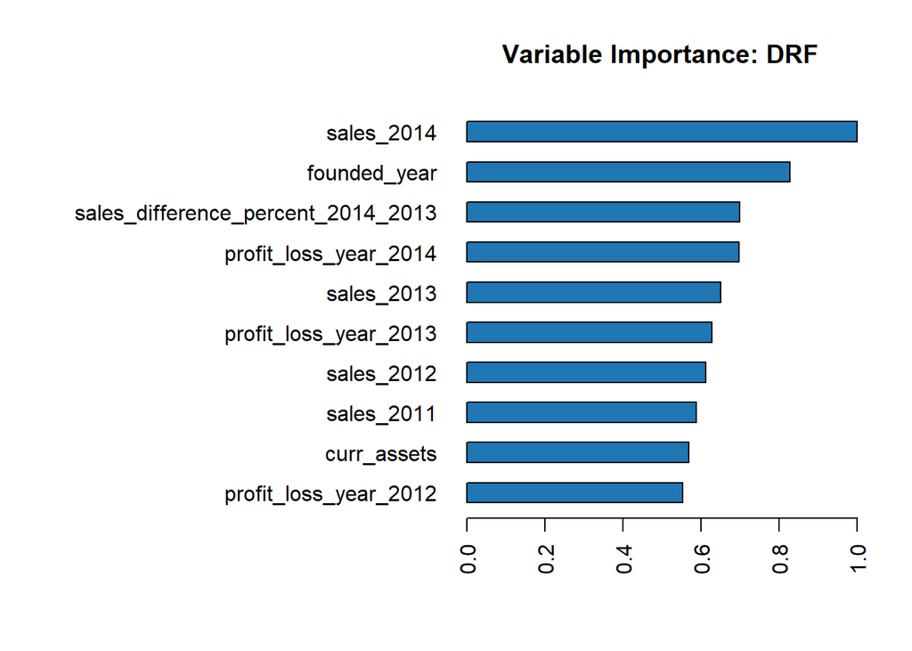

```r
h2o.varimp_plot(rfHex)
```

## Predict with the models and evaluate their results on the TEST SET:

#### GLMnet model predictions:

```r
#predict actuall outcomes:
predicted_glmnet_actual <- predict.train(glmnet_model, newdata = data_test)
#predict prbabilities:
predicted_glmnet_prob <- predict.train(glmnet_model, newdata = data_test, type = "prob")

#write back the results to the test data:
data_test$gmlnet_bankrupt_actual <- predicted_glmnet_actual

#write back the results to the test data:
data_test$gmlnet_bankrupt_prob <- predicted_glmnet_prob$Yes
```

#### Simple decision Tree model predictions:

```r
#predict actuall outcomes:
predicted_tree_actual <- predict.train(rpart_model, newdata = data_test)
#predict prbabilities:
predicted_tree_prob <- predict.train(rpart_model, newdata = data_test, type = "prob")

#write back the results to the test data:
data_test$tree_bankrupt_actual <- predicted_tree_actual

#write back the results to the test data:
data_test$tree_bankrupt_prob <- predicted_tree_prob$Yes
```

#### RandomForest predictions:

```r
testHex<-as.h2o(data_test)
predictions_h2o <- as.data.frame(h2o.predict(rfHex,testHex))

#write back the results to the test data:
data_test$rf_bankrupt_actual <- predictions_h2o$predict

#write back the results to the test data:
data_test$rf_bankrupt_prob <- predictions_h2o$Yes
```

## EVALUETE THE MODELS ON THE TEST SET:

#### GLMnet ROC curve:

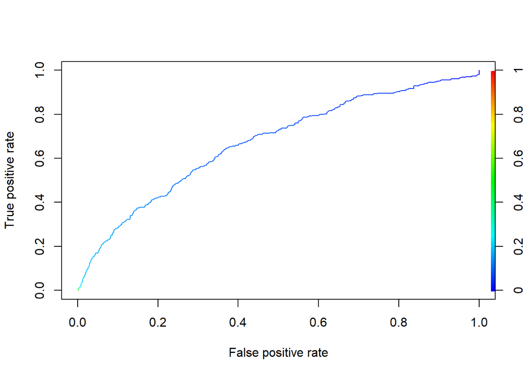

```r
rocr_prediction_glm <- prediction(data_test$gmlnet_bankrupt_prob,
                              data_test$bankrupt)
# built-in plot method
plot(performance(rocr_prediction_glm, "tpr", "fpr"), colorize=TRUE)
```

#### Tree ROC curve:

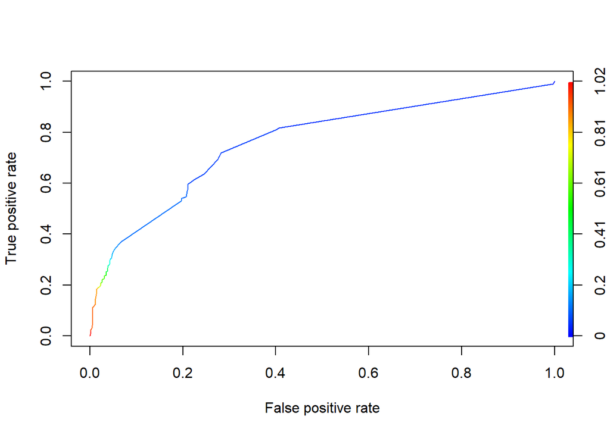

```r
rocr_prediction_tree <- prediction(data_test$tree_bankrupt_prob,
                              data_test$bankrupt)
# built-in plot method
plot(performance(rocr_prediction_tree, "tpr", "fpr"), colorize=TRUE)
```

#### RandomForest ROC curve:

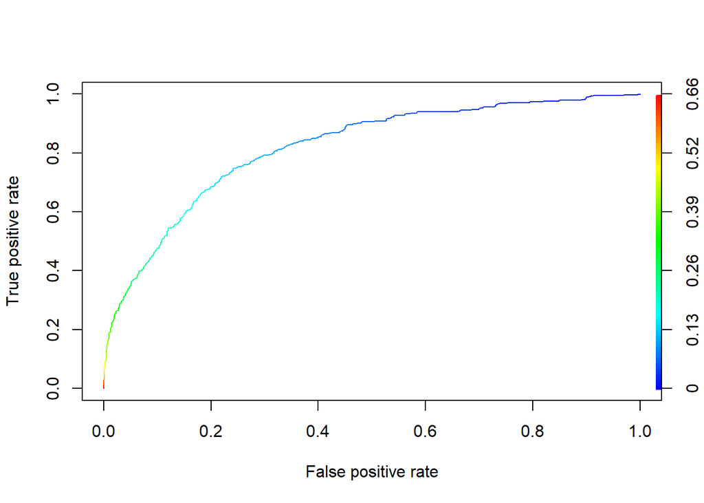

```r
rocr_prediction_randf<- prediction(data_test$rf_bankrupt_prob,
                              data_test$bankrupt)
# built-in plot method
plot(performance(rocr_prediction_randf, "tpr", "fpr"), colorize=TRUE)
```

Plot together:

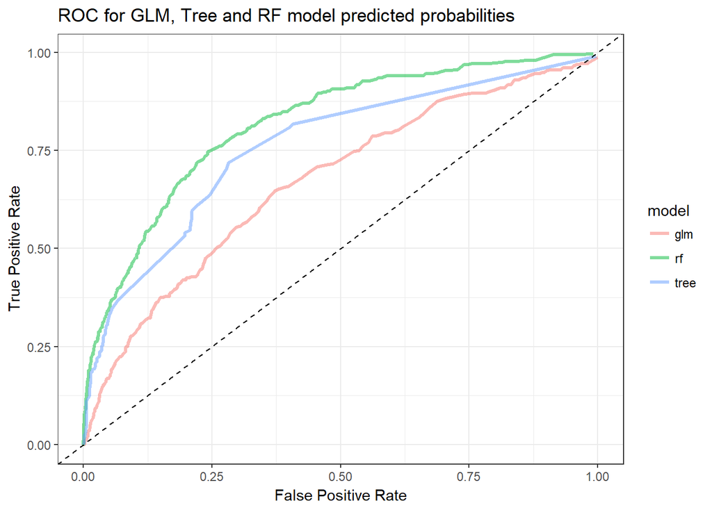

```r
thresholds <- seq(0, 1, by = 0.001)

test_truth <- data_test$bankrupt_yes_no

true_positive_rates_glm <- rep(0, length(thresholds))
false_positive_rates_glm <- rep(0, length(thresholds))

true_positive_rates_tree <- rep(0, length(thresholds))
false_positive_rates_tree <- rep(0, length(thresholds))

true_positive_rates_rf <- rep(0, length(thresholds))
false_positive_rates_rf <- rep(0, length(thresholds))

for (ix in 1:length(thresholds)) {
  thr <- thresholds[ix]
  test_prediction_glm_net <- ifelse(data_test$gmlnet_bankrupt_prob > thr, "Yes", "No")
  test_prediction_glm_net <- factor(test_prediction_glm_net, levels = c("Yes", "No"))

    test_prediction_tree <- ifelse(data_test$tree_bankrupt_prob > thr, "Yes", "No")
  test_prediction_tree <- factor(test_prediction_tree, levels = c("Yes", "No"))

  test_prediction_rf <- ifelse(data_test$rf_bankrupt_prob > thr, "Yes", "No")
  test_prediction_rf <- factor(test_prediction_rf, levels = c("Yes", "No"))

  cm <- as.matrix(confusionMatrix(test_prediction_glm_net, test_truth))
  cm2 <- as.matrix(confusionMatrix(test_prediction_tree, test_truth))
  cm3 <- as.matrix(confusionMatrix(test_prediction_rf, test_truth))

  true_positive_rates_glm[ix] <- cm[1, 1] / (cm[1, 1] + cm[2, 1])
  false_positive_rates_glm[ix] <- cm[1, 2] / (cm[1, 2] + cm[2, 2])

  true_positive_rates_tree[ix] <- cm2[1, 1] / (cm2[1, 1] + cm2[2, 1])
  false_positive_rates_tree[ix] <- cm2[1, 2] / (cm2[1, 2] + cm2[2, 2])

  true_positive_rates_rf[ix] <- cm3[1, 1] / (cm3[1, 1] + cm3[2, 1])
  false_positive_rates_rf[ix] <- cm3[1, 2] / (cm3[1, 2] + cm3[2, 2])

}


roc1 <- data.table("threshold" = thresholds,
                   "true_positive_rate" = true_positive_rates_glm,
                   "false_positive_rate" = false_positive_rates_glm,
                   "model" = "glm")

roc2 <- data.table("threshold" = thresholds,
                   "true_positive_rate" = true_positive_rates_tree,
                   "false_positive_rate" = false_positive_rates_tree,
                   "model" = "tree")

roc3 <- data.table("threshold" = thresholds,
                   "true_positive_rate"= true_positive_rates_rf,
                   "false_positive_rate" = false_positive_rates_rf,
                   "model" = "rf")

roc_all <- rbind(roc1, roc2, roc3)


ggplot(data = roc_all,
       aes(x = false_positive_rate,
           y = true_positive_rate,
           color = model)) +
  geom_line(size = 1.2, alpha = 0.5) +
  geom_abline(slope = 1, color = "black", linetype = 2) +
  labs(x="False Positive Rate", y="True Positive Rate")+ ggtitle("ROC for GLM, Tree and RF model predicted probabilities")
```

RandomForrest model has the highest AUC therefore RandomForrest is the best model considering this method to decide which model is the best on this data.

We also, can compute the area under the curve (AUC):

```r
AUC_glm <- performance(rocr_prediction_glm, "auc")

AUC_tree <- performance(rocr_prediction_tree, "auc")

AUC_rf <- performance(rocr_prediction_randf, "auc")

table0 <- data.table(Models = c("GLM", "Single Tree", "RandomForest"), AUC = c(AUC_glm@y.values[[1]], AUC_tree@y.values[[1]], AUC_rf@y.values[[1]]))

kable(table0, align = 'c', digits = 4)
```

| Models | AUC |
| --- | --- |
| GLM | 0.6712 |
| Single Tree | 0.7601 |
| RandomForest | 0.8181 |

## Calibration plot for the RandomForest model:

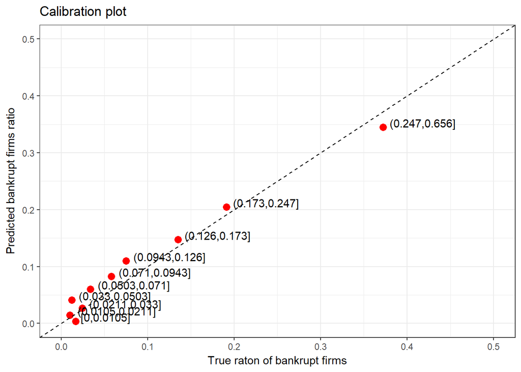

```r
deciles <- quantile(data_test$rf_bankrupt_prob, prob = seq(0, 1, length = 11))

group <- cut(data_test$rf_bankrupt_prob, deciles, include.lowest = TRUE)

data_test[, prediction_normal_group := group]

calibrateplot <- data_test[, .(N = .N, true_mean_bankrupt = mean(bankrupt), predicted_mean_bankrupt = mean(rf_bankrupt_prob)), by = prediction_normal_group]

ggplot(calibrateplot, aes(x= true_mean_bankrupt, y=predicted_mean_bankrupt)) + geom_point(size = 3, color = "red")+ geom_text(aes(label=prediction_normal_group),hjust=-0.1, vjust=0) + geom_abline(slope = 1, linetype = 2) + coord_cartesian(xlim = c(0, 0.5), ylim = c(0,0.5)) + labs(x="True raton of bankrupt firms", y="Predicted bankrupt firms ratio") + ggtitle("Calibration plot")
```

We can see that in the center of our graph our model is overestimates and at very right site is underestimates, but all in all from my point of view it is well calibration plot and a well calibrated model.

## We also can calculate the brier score of our models and we can compare them:

Define brier score:

```r
BRIER_SCORE <- function(x, true_x) sqrt(mean((x - true_x)^2))
```

Calculate Brier Score for each model:

```r
brier_glm <- BRIER_SCORE(data_test$gmlnet_bankrupt_prob,data_test$bankrupt)
brier_tree <- BRIER_SCORE(data_test$tree_bankrupt_prob,data_test$bankrupt)
brier_rf <- BRIER_SCORE(data_test$rf_bankrupt_prob,data_test$bankrupt)

#put it to a table:

table1 <- data.table(Models = c("GLM", "Single Tree", "RandomForest"), Brier_Score = c(brier_glm, brier_tree, brier_rf))

kable(table1, align = 'c', digits = 4)
```

| Models | Brier_Score |
| --- | --- |
| GLM | 0.2878 |
| Single Tree | 0.2851 |
| RandomForest | 0.2653 |

Lower Brier score is better. Based on this also the RandomForrest model seems the best

In the next part I am creating confusion matrices for the randomForest model:

## Confusion Matrix:

#### For the RandomForest model:

```r
confusionMatrix(data_test$rf_bankrupt_actual, data_test$bankrupt_yes_no)
```

```
## Confusion Matrix and Statistics
##
##           Reference
## Prediction  Yes   No
##        Yes  180  367
##        No   204 3384
##
##                Accuracy : 0.8619
##                  95% CI : (0.851, 0.8723)
##     No Information Rate : 0.9071
##     P-Value [Acc > NIR] : 1
##
##                   Kappa : 0.3116
##  Mcnemar's Test P-Value : 0.00000000001206
##
##             Sensitivity : 0.46875
##             Specificity : 0.90216
##          Pos Pred Value : 0.32907
##          Neg Pred Value : 0.94314
##              Prevalence : 0.09287
##          Detection Rate : 0.04353
##    Detection Prevalence : 0.13229
##       Balanced Accuracy : 0.68545
##
##        'Positive' Class : Yes
##
```

If our goal is not to make our best prediction we can try to adjust the threshold when we want to classify a firm as bankrupt.

If lets say a business decision is that we want to avoid bankrupt firms it is a better method.

```r
data_test[, predicted_1_0_rf_adjustted := ifelse(rf_bankrupt_prob > 0.12, "Yes", "No")]
confusionMatrix(data_test$predicted_1_0_rf_adjustted, data_test$bankrupt_yes_no)
```

```
## Confusion Matrix and Statistics
##
##           Reference
## Prediction  Yes   No
##        Yes  295 1026
##        No    89 2725
##
##                Accuracy : 0.7304
##                  95% CI : (0.7165, 0.7438)
##     No Information Rate : 0.9071
##     P-Value [Acc > NIR] : 1
##
##                   Kappa : 0.2361
##  Mcnemar's Test P-Value : <0.0000000000000002
##
##             Sensitivity : 0.76823
##             Specificity : 0.72647
##          Pos Pred Value : 0.22332
##          Neg Pred Value : 0.96837
##              Prevalence : 0.09287
##          Detection Rate : 0.07134
##    Detection Prevalence : 0.31947
##       Balanced Accuracy : 0.74735
##
##        'Positive' Class : Yes
##
```

## Summary:

In this exercise I trained 3 models and evaluated their results. I found out that the RandomForrest model performed the best from my point of view.